# Machine Learning Project 2024

Authors

Lucas Jakin

Saša Nanut

Luca Marega

Published

July 12, 2024

# Predicting next-day rain in Australia

#### Introduction

As a group we decided to take on the **first project type**. The project focuses on utilizing DM & ML algorithms to address a specific problem chosen from Kaggle.The Goal of the project is to address the classification problem by utilizing more than one classification algorithm, in order to do a systematic experimentation with different algorithms to identify in what they differ and which one is the most effective one for the chosen dataset. We will consider different classification algorithms and make the comparison between three of them, more precisely *Artificial Neural Networks*, *CatBoost* and *Logistic Regression*.

We will divide the work as the following: as a group we will perform a brief analysis of the dataset and make some cleaning of it if needed. Afterwards, each one of us will implement one of the previously mentioned algorithms and then we will compare and interpret the results

## About the dataset

The dataset found in [Kaggle](https://www.kaggle.com/datasets/jsphyg/weather-dataset-rattle-package/code) consists of about 10 years of daily weather observations from numerous locations across Australia.

The problem that is required to be solved from this dataset represents a classification problem, in this case a **binary classification** problem. The objective is to predict whether it will rain tomorrow or not with high accuracy. The dataframe contains 145460 observations (rows) and 23 attributes. The observations are weather conditions of days of a specific region including: date, location, minimum and maximum temperature, rain fall, humidity and so on.

The most important feature of the dataset is the last column **“RainTomorrow”**, which is the target variable for our ML models that we want to predict.

It has two values:

- Yes –> It will rain tomorrow
- No –> It will not rain tomorrow.

## Exploratory Data Analysis

```r
library(tidyverse)
library(dplyr)
library(skimr)
library(ggcorrplot)
library(gt)
library(ggplot2)

#use_python("C:\\Python312\python.exe", required = T)
weatherAus <- read.csv("weatherAUS.csv", header = T)
```

Setting up python into Rstudio:

```r
# SETTING UP PYTHON ON RSTUDIO
library(reticulate)

virtualenv_create("my-python", python_version = "3.12")
use_virtualenv("my-python", required = TRUE)

#virtualenv_install(envname = "my-python", "matplotlib",ignore_installed = FALSE, pip_options = character())

#virtualenv_install(envname = "my-python", "catboost",ignore_installed = FALSE, pip_options = character())

#virtualenv_install(envname = "my-python", "numpy",ignore_installed = FALSE, pip_options = character())

#virtualenv_install(envname = "my-python", "pandas",ignore_installed = FALSE, pip_options = character())

#virtualenv_install(envname = "my-python", "seaborn",ignore_installed = FALSE, pip_options = character())

#virtualenv_install(envname = "my-python", "scikit-learn",ignore_installed = FALSE, pip_options = character())

#virtualenv_install(envname = "my-python", "tensorflow",ignore_installed = FALSE, pip_options = character())
```

As we start, we first load the weather data and look at the first rows to identify the features:

```r
head(weatherAus) %>% gt()
```

| Date | Location | MinTemp | MaxTemp | Rainfall | Evaporation | Sunshine | WindGustDir | WindGustSpeed | WindDir9am | WindDir3pm | WindSpeed9am | WindSpeed3pm | Humidity9am | Humidity3pm | Pressure9am | Pressure3pm | Cloud9am | Cloud3pm | Temp9am | Temp3pm | RainToday | RainTomorrow |
| --- | --- | --- | --- | --- | --- | --- | --- | --- | --- | --- | --- | --- | --- | --- | --- | --- | --- | --- | --- | --- | --- | --- |
| 2008-12-01 | Albury | 13.4 | 22.9 | 0.6 | NA | NA | W | 44 | W | WNW | 20 | 24 | 71 | 22 | 1007.7 | 1007.1 | 8 | NA | 16.9 | 21.8 | No | No |
| 2008-12-02 | Albury | 7.4 | 25.1 | 0.0 | NA | NA | WNW | 44 | NNW | WSW | 4 | 22 | 44 | 25 | 1010.6 | 1007.8 | NA | NA | 17.2 | 24.3 | No | No |
| 2008-12-03 | Albury | 12.9 | 25.7 | 0.0 | NA | NA | WSW | 46 | W | WSW | 19 | 26 | 38 | 30 | 1007.6 | 1008.7 | NA | 2 | 21.0 | 23.2 | No | No |
| 2008-12-04 | Albury | 9.2 | 28.0 | 0.0 | NA | NA | NE | 24 | SE | E | 11 | 9 | 45 | 16 | 1017.6 | 1012.8 | NA | NA | 18.1 | 26.5 | No | No |
| 2008-12-05 | Albury | 17.5 | 32.3 | 1.0 | NA | NA | W | 41 | ENE | NW | 7 | 20 | 82 | 33 | 1010.8 | 1006.0 | 7 | 8 | 17.8 | 29.7 | No | No |
| 2008-12-06 | Albury | 14.6 | 29.7 | 0.2 | NA | NA | WNW | 56 | W | W | 19 | 24 | 55 | 23 | 1009.2 | 1005.4 | NA | NA | 20.6 | 28.9 | No | No |

In the next step we check out the summary statistics of the dataset and identify the numerical and categorical attributes:

```r
skim(weatherAus)
```

Data summary

| Name | weatherAus |
| --- | --- |
| Number of rows | 145460 |
| Number of columns | 23 |
| _______________________ |  |
| Column type frequency: |  |
| character | 7 |
| numeric | 16 |
| ________________________ |  |
| Group variables | None |

**Variable type: character**

| skim_variable | n_missing | complete_rate | min | max | empty | n_unique | whitespace |
| --- | --- | --- | --- | --- | --- | --- | --- |
| Date | 0 | 1.00 | 10 | 10 | 0 | 3436 | 0 |
| Location | 0 | 1.00 | 4 | 16 | 0 | 49 | 0 |
| WindGustDir | 10326 | 0.93 | 1 | 3 | 0 | 16 | 0 |
| WindDir9am | 10566 | 0.93 | 1 | 3 | 0 | 16 | 0 |
| WindDir3pm | 4228 | 0.97 | 1 | 3 | 0 | 16 | 0 |
| RainToday | 3261 | 0.98 | 2 | 3 | 0 | 2 | 0 |
| RainTomorrow | 3267 | 0.98 | 2 | 3 | 0 | 2 | 0 |

**Variable type: numeric**

| skim_variable | n_missing | complete_rate | mean | sd | p0 | p25 | p50 | p75 | p100 | hist |
| --- | --- | --- | --- | --- | --- | --- | --- | --- | --- | --- |
| MinTemp | 1485 | 0.99 | 12.19 | 6.40 | -8.5 | 7.6 | 12.0 | 16.9 | 33.9 | ▁▅▇▅▁ |
| MaxTemp | 1261 | 0.99 | 23.22 | 7.12 | -4.8 | 17.9 | 22.6 | 28.2 | 48.1 | ▁▂▇▅▁ |
| Rainfall | 3261 | 0.98 | 2.36 | 8.48 | 0.0 | 0.0 | 0.0 | 0.8 | 371.0 | ▇▁▁▁▁ |
| Evaporation | 62790 | 0.57 | 5.47 | 4.19 | 0.0 | 2.6 | 4.8 | 7.4 | 145.0 | ▇▁▁▁▁ |
| Sunshine | 69835 | 0.52 | 7.61 | 3.79 | 0.0 | 4.8 | 8.4 | 10.6 | 14.5 | ▃▃▅▇▃ |
| WindGustSpeed | 10263 | 0.93 | 40.04 | 13.61 | 6.0 | 31.0 | 39.0 | 48.0 | 135.0 | ▅▇▁▁▁ |
| WindSpeed9am | 1767 | 0.99 | 14.04 | 8.92 | 0.0 | 7.0 | 13.0 | 19.0 | 130.0 | ▇▁▁▁▁ |
| WindSpeed3pm | 3062 | 0.98 | 18.66 | 8.81 | 0.0 | 13.0 | 19.0 | 24.0 | 87.0 | ▇▇▁▁▁ |
| Humidity9am | 2654 | 0.98 | 68.88 | 19.03 | 0.0 | 57.0 | 70.0 | 83.0 | 100.0 | ▁▁▅▇▆ |
| Humidity3pm | 4507 | 0.97 | 51.54 | 20.80 | 0.0 | 37.0 | 52.0 | 66.0 | 100.0 | ▂▅▇▆▂ |
| Pressure9am | 15065 | 0.90 | 1017.65 | 7.11 | 980.5 | 1012.9 | 1017.6 | 1022.4 | 1041.0 | ▁▁▇▇▁ |
| Pressure3pm | 15028 | 0.90 | 1015.26 | 7.04 | 977.1 | 1010.4 | 1015.2 | 1020.0 | 1039.6 | ▁▁▇▇▁ |
| Cloud9am | 55888 | 0.62 | 4.45 | 2.89 | 0.0 | 1.0 | 5.0 | 7.0 | 9.0 | ▇▃▃▇▅ |
| Cloud3pm | 59358 | 0.59 | 4.51 | 2.72 | 0.0 | 2.0 | 5.0 | 7.0 | 9.0 | ▆▅▃▇▃ |
| Temp9am | 1767 | 0.99 | 16.99 | 6.49 | -7.2 | 12.3 | 16.7 | 21.6 | 40.2 | ▁▃▇▃▁ |
| Temp3pm | 3609 | 0.98 | 21.68 | 6.94 | -5.4 | 16.6 | 21.1 | 26.4 | 46.7 | ▁▃▇▃▁ |

As we can see from the figure above, there are 7 **categorical** attributes and 16 **numerical** attributes.  
Before taking a deeper look on all other attributes, we first did a brief exploration of the target variable:

- **MISSING VALUES**

```r
missingValues <- sum(is.na(weatherAus$RainTomorrow))
missingValues
```

```
[1] 3267
```

- **FREQUENCY DISTRIBUTION OF VALUES**

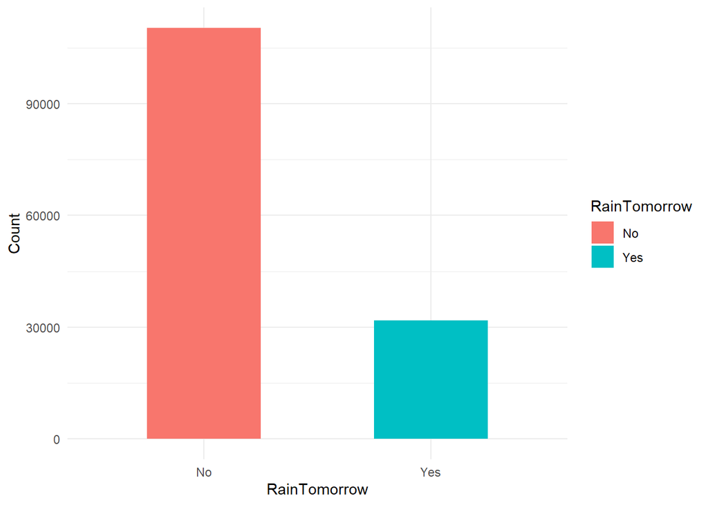

```r
  weatherAus %>% select(RainTomorrow) %>%
  count(RainTomorrow) %>% drop_na() %>%
  ggplot(., aes(RainTomorrow, n, fill=RainTomorrow)) +
  geom_col(width = 0.5)+
  labs(x = "RainTomorrow", y = "Count")+
  theme_minimal()
```

- **RATIO OF FREQUENCY DISTRIBUTION**

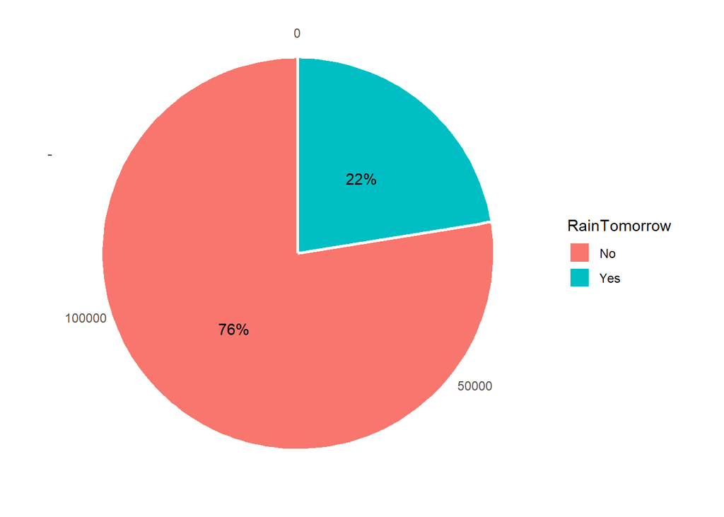

```r
  weatherAus %>% select(RainTomorrow) %>%
  count(RainTomorrow) %>% drop_na() %>%
  ggplot(., aes(x="", n, fill = RainTomorrow)) +
  geom_bar(width = 1, size = 1, color = "white",stat = "identity") + coord_polar("y", start = 0) +
  geom_text(aes(label = paste0(round((n/145460)*100),"%")),
            position = position_stack(vjust = 0.5)) +
  theme_classic() +
  labs(x = NULL, y = NULL) +
  theme(axis.line = element_blank())
```

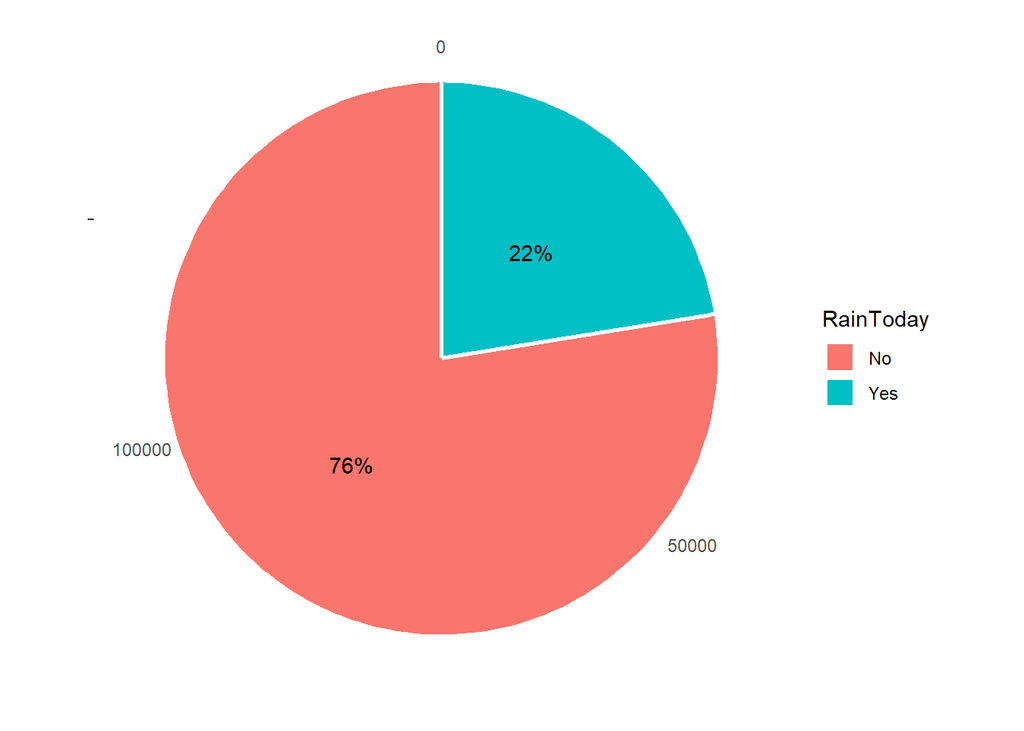

```r
  weatherAus %>% select(RainToday) %>%
  count(RainToday) %>% drop_na() %>%
  ggplot(., aes(x="", n, fill = RainToday)) +
  geom_bar(width = 1, size = 1, color = "white",stat = "identity") + coord_polar("y", start = 0) +
  geom_text(aes(label = paste0(round((n/145460)*100),"%")),
            position = position_stack(vjust = 0.5)) +
  theme_classic() +
  labs(x = NULL, y = NULL) +
  theme(axis.line = element_blank())
```

The variable **RainToday** has a very similar value distribution as the target variable.

### Categorical values

All together there are 6 categorical features + a Date column. In order to make the information about the date more useful, we decided to extract the year, the month and the day from the date into three separate columns.  
This is done here below:

```r
weatherAusNew <- weatherAus %>% mutate(
  Year = year(Date),
  Month = month(Date),
  Day = day(Date)
) %>% select(-Date)
as_tibble(weatherAusNew)
```

```
# A tibble: 145,460 × 25
   Location MinTemp MaxTemp Rainfall Evaporation Sunshine WindGustDir
   <chr>      <dbl>   <dbl>    <dbl>       <dbl>    <dbl> <chr>
 1 Albury      13.4    22.9      0.6          NA       NA W
 2 Albury       7.4    25.1      0            NA       NA WNW
 3 Albury      12.9    25.7      0            NA       NA WSW
 4 Albury       9.2    28        0            NA       NA NE
 5 Albury      17.5    32.3      1            NA       NA W
 6 Albury      14.6    29.7      0.2          NA       NA WNW
 7 Albury      14.3    25        0            NA       NA W
 8 Albury       7.7    26.7      0            NA       NA W
 9 Albury       9.7    31.9      0            NA       NA NNW
10 Albury      13.1    30.1      1.4          NA       NA W
# ℹ 145,450 more rows
# ℹ 18 more variables: WindGustSpeed <int>, WindDir9am <chr>, WindDir3pm <chr>,
#   WindSpeed9am <int>, WindSpeed3pm <int>, Humidity9am <int>,
#   Humidity3pm <int>, Pressure9am <dbl>, Pressure3pm <dbl>, Cloud9am <int>,
#   Cloud3pm <int>, Temp9am <dbl>, Temp3pm <dbl>, RainToday <chr>,
#   RainTomorrow <chr>, Year <dbl>, Month <dbl>, Day <int>
```

### Numerical values

There are 16 numerical attributes in the raw dataset, after adding three columns for year, month and day, there are in total 19 numerical attributes. The main goal when analyzing numerical data is to find the outliers. Outliers are data information that differ significantly from other observations.

The most efficient way to detect outliers is to draw box plots:

> MinTemp

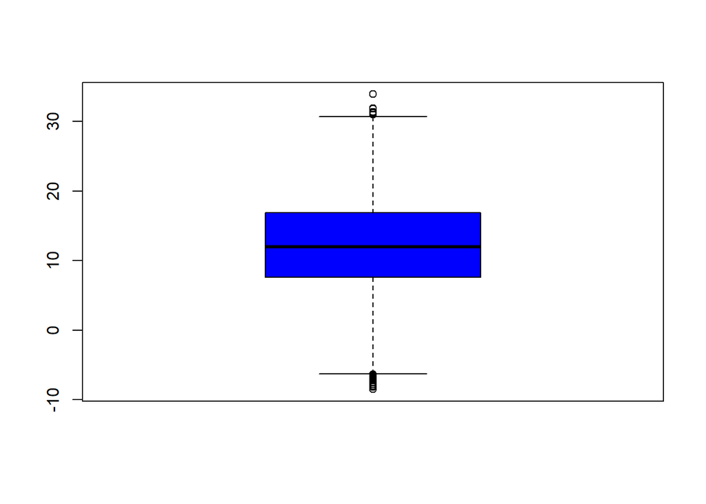

```r
 boxplot(weatherAusNew$MinTemp, col = "blue", border = "black")
```

> MaxTemp

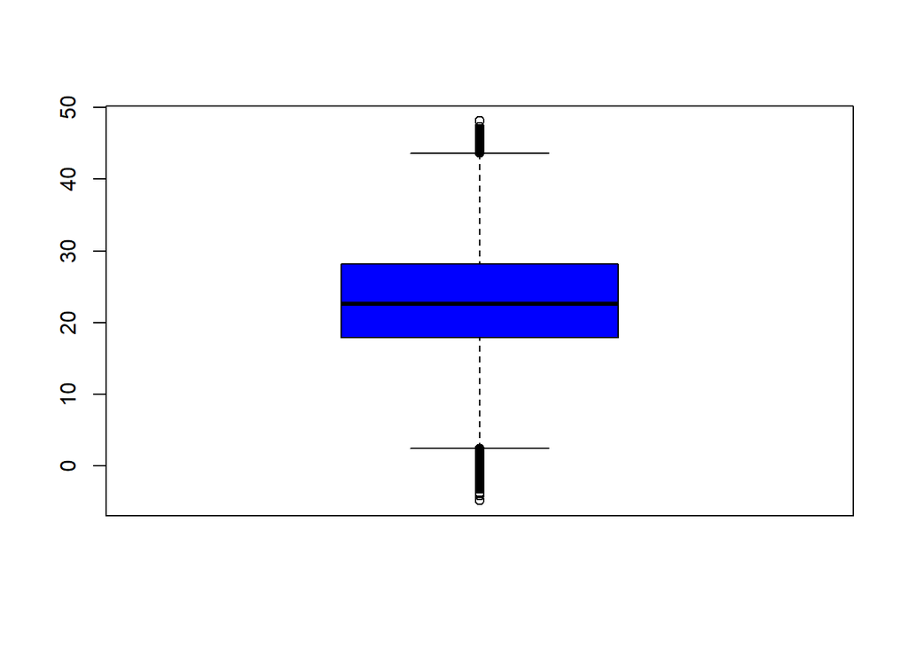

```r
 boxplot(weatherAusNew$MaxTemp, col = "blue", border = "black")
```

> Rainfall

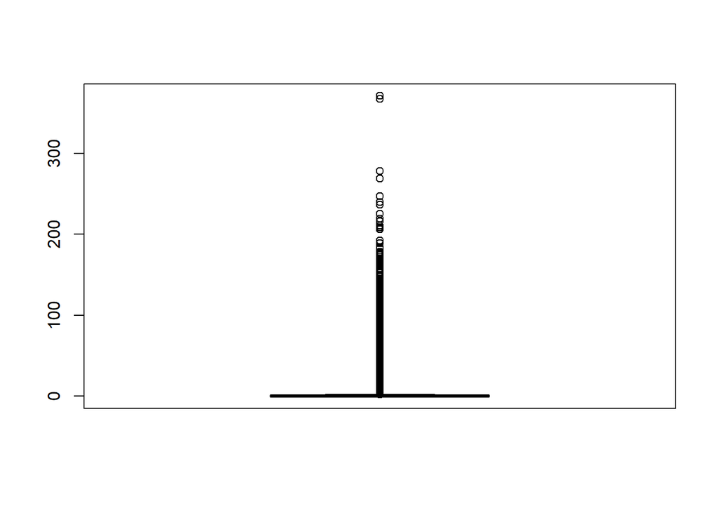

```r
 boxplot(weatherAusNew$Rainfall, col = "blue", border = "black")
```

> Evaporation

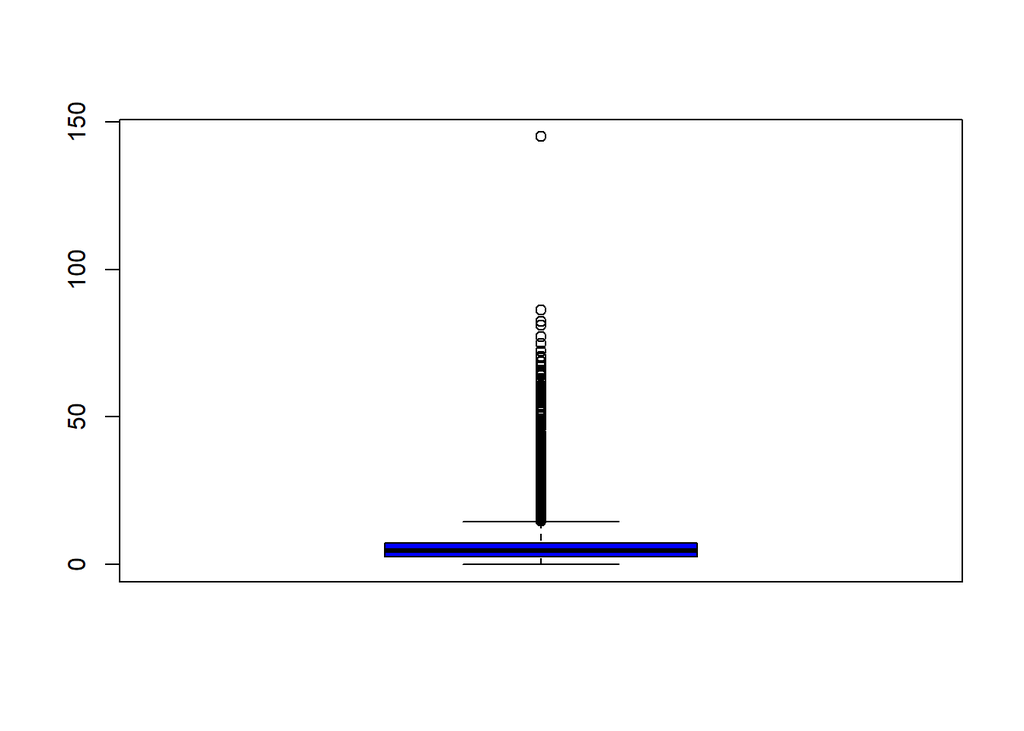

```r
 boxplot(weatherAusNew$Evaporation, col = "blue", border = "black")
```

> Sunshine

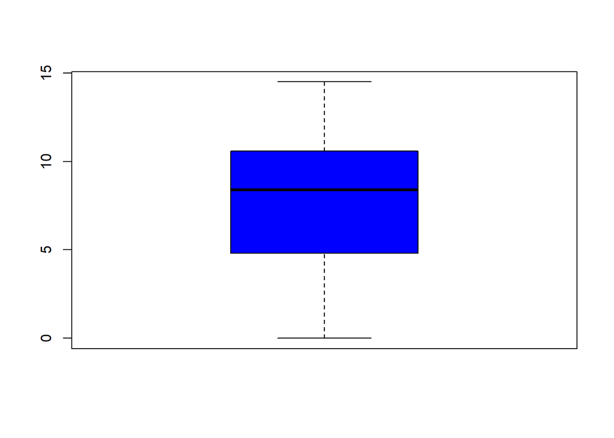

```r
 boxplot(weatherAusNew$Sunshine, col = "blue", border = "black")
```

> WindGustSpeed

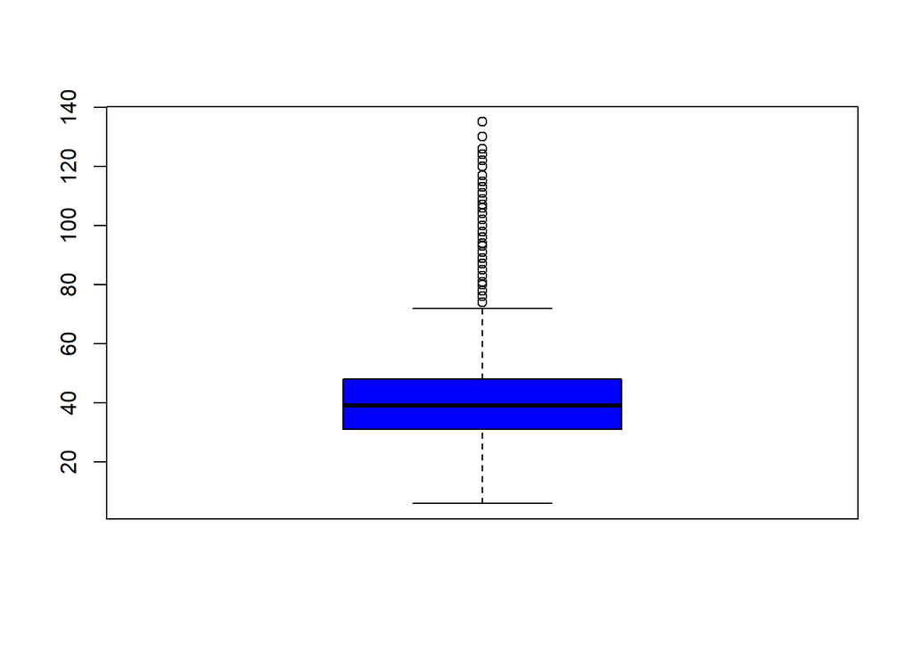

```r
 boxplot(weatherAusNew$WindGustSpeed, col = "blue", border = "black")
```

> WindSpeed9am

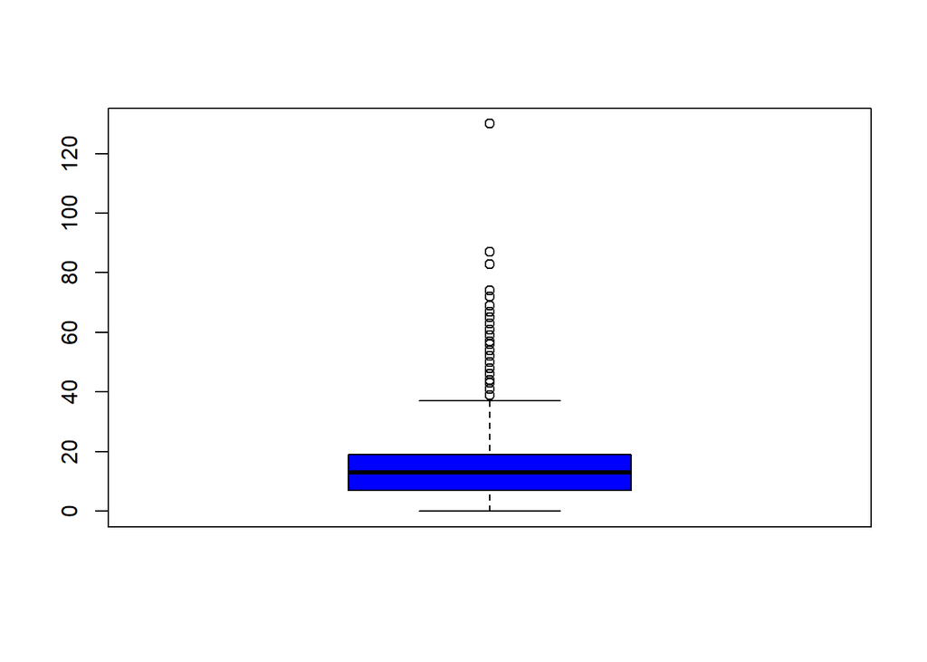

```r
 boxplot(weatherAusNew$WindSpeed9am, col = "blue", border = "black")
```

> WindSpeed3pm

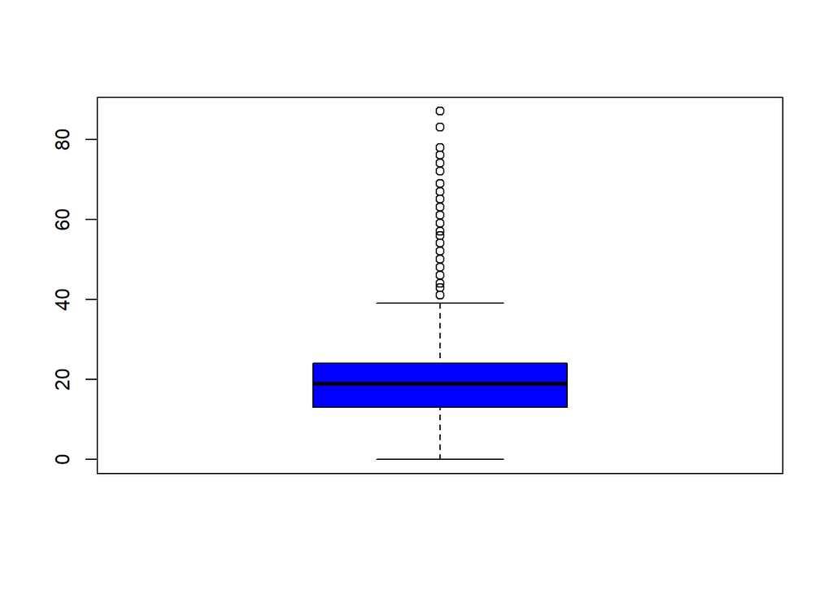

```r
 boxplot(weatherAusNew$WindSpeed3pm, col = "blue", border = "black")
```

> Humidity9am

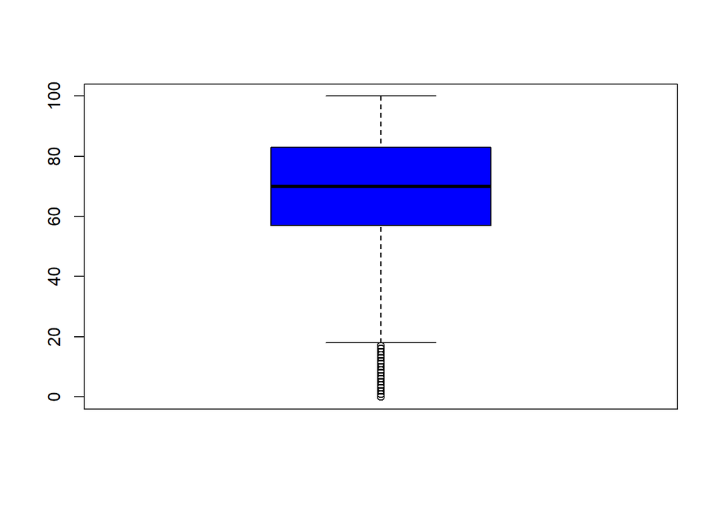

```r
 boxplot(weatherAusNew$Humidity9am, col = "blue", border = "black")
```

> Humidity3pm

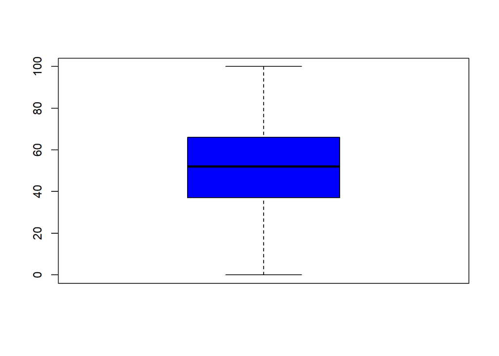

```r
 boxplot(weatherAusNew$Humidity3pm, col = "blue", border = "black")
```

> Pressure9am

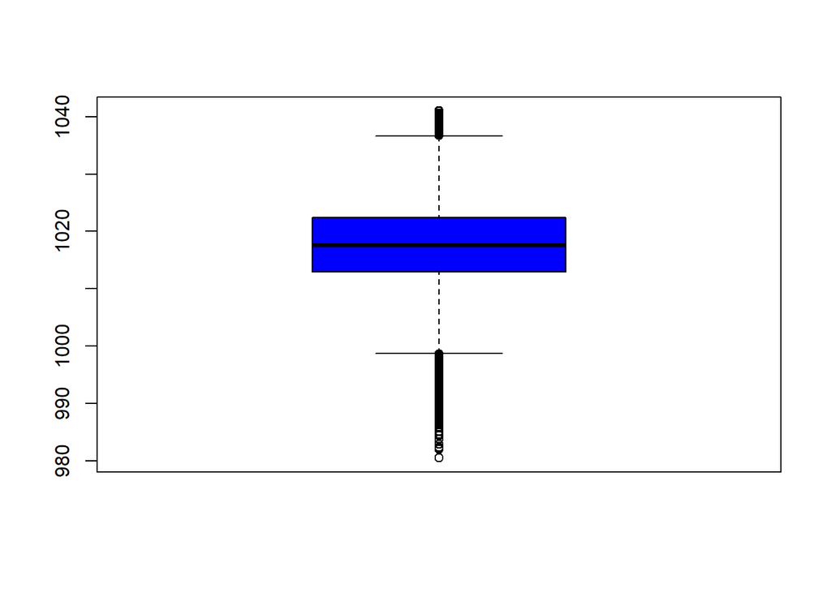

```r
 boxplot(weatherAusNew$Pressure9am, col = "blue", border = "black")
```

> Pressure3pm

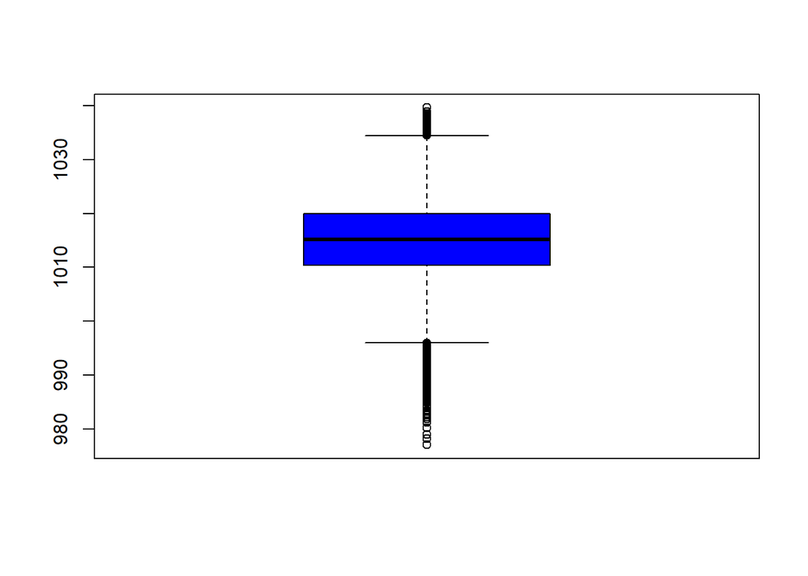

```r
 boxplot(weatherAusNew$Pressure3pm, col = "blue", border = "black")
```

> Cloud9am

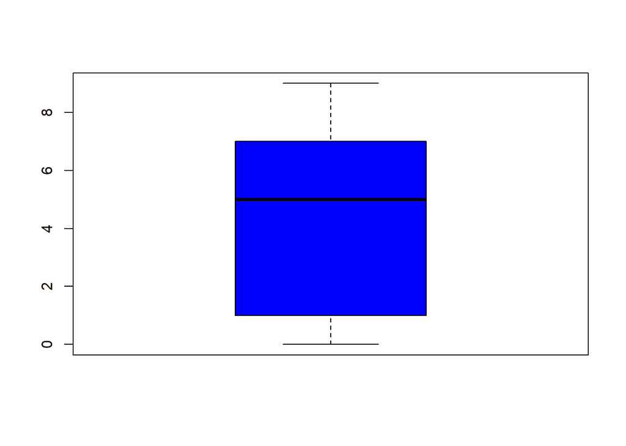

```r
 boxplot(weatherAusNew$Cloud9am, col = "blue", border = "black")
```

> Cloud3pm

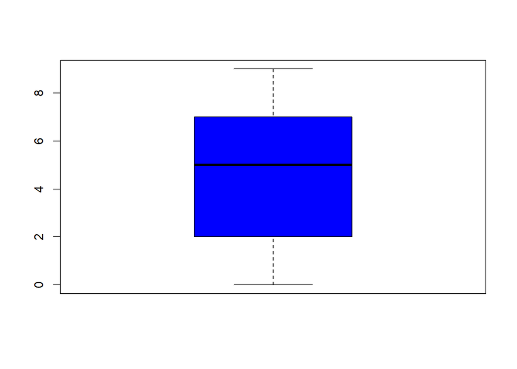

```r
 boxplot(weatherAusNew$Cloud3pm, col = "blue", border = "black")
```

> Temp9am

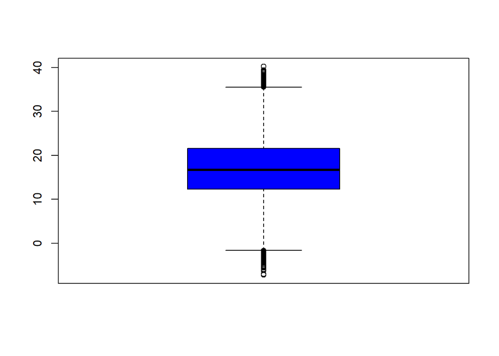

```r
 boxplot(weatherAusNew$Temp9am, col = "blue", border = "black")
```

> Temp3pm

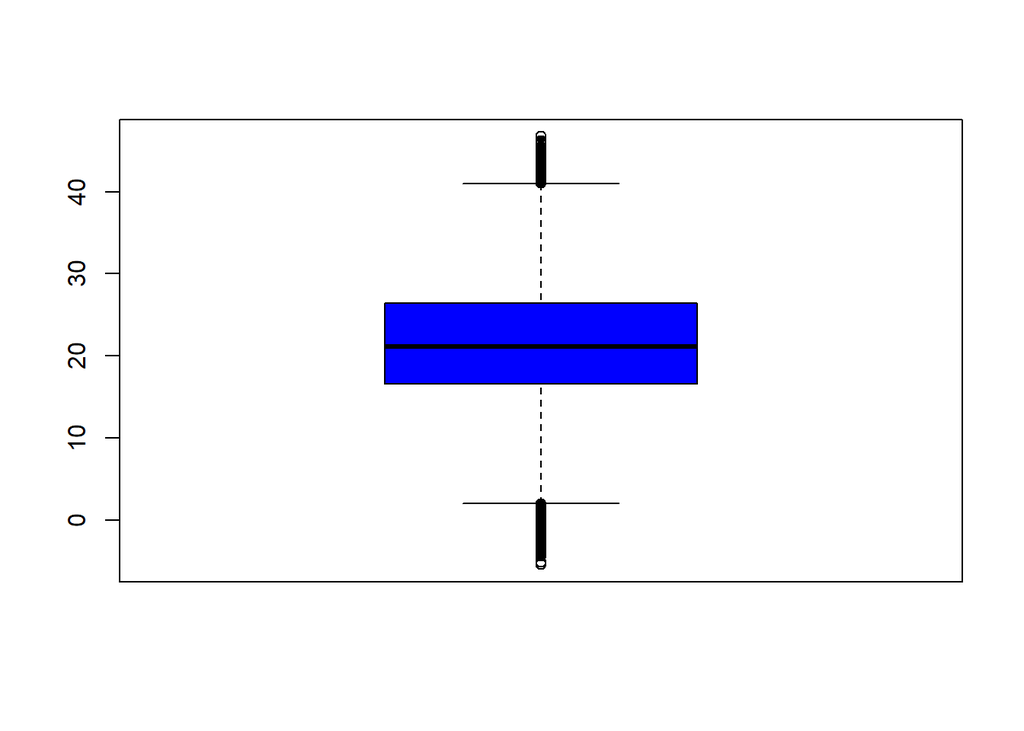

```r
 boxplot(weatherAusNew$Temp3pm, col = "blue", border = "black")
```

> Year

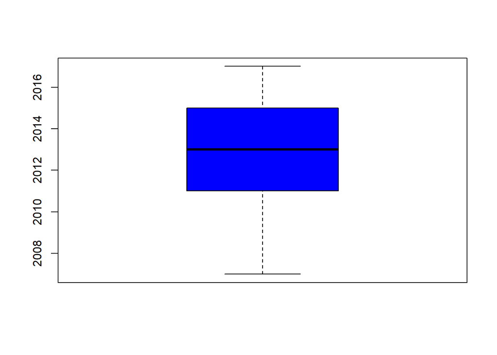

```r
 boxplot(weatherAusNew$Year, col = "blue", border = "black")
```

> Month

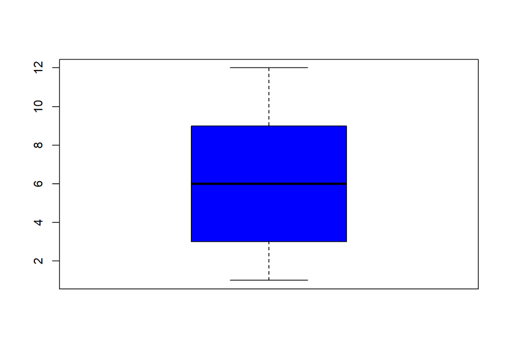

```r
 boxplot(weatherAusNew$Month, col = "blue", border = "black")
```

> Day

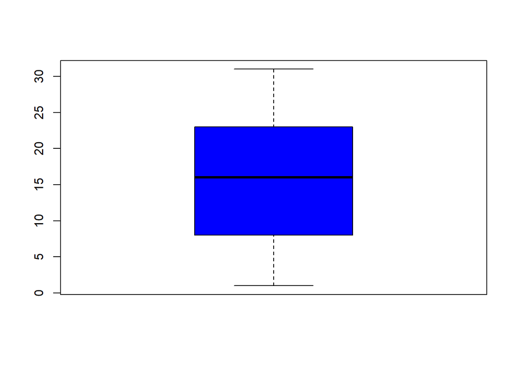

```r
 boxplot(weatherAusNew$Day, col = "blue", border = "black")
```

### Multicollinearity

```
 [1] "Location"      "MinTemp"       "MaxTemp"       "Rainfall"
 [5] "Evaporation"   "Sunshine"      "WindGustDir"   "WindGustSpeed"
 [9] "WindDir9am"    "WindDir3pm"    "WindSpeed9am"  "WindSpeed3pm"
[13] "Humidity9am"   "Humidity3pm"   "Pressure9am"   "Pressure3pm"
[17] "Cloud9am"      "Cloud3pm"      "Temp9am"       "Temp3pm"
[21] "RainToday"     "RainTomorrow"  "Year"          "Month"
[25] "Day"
```

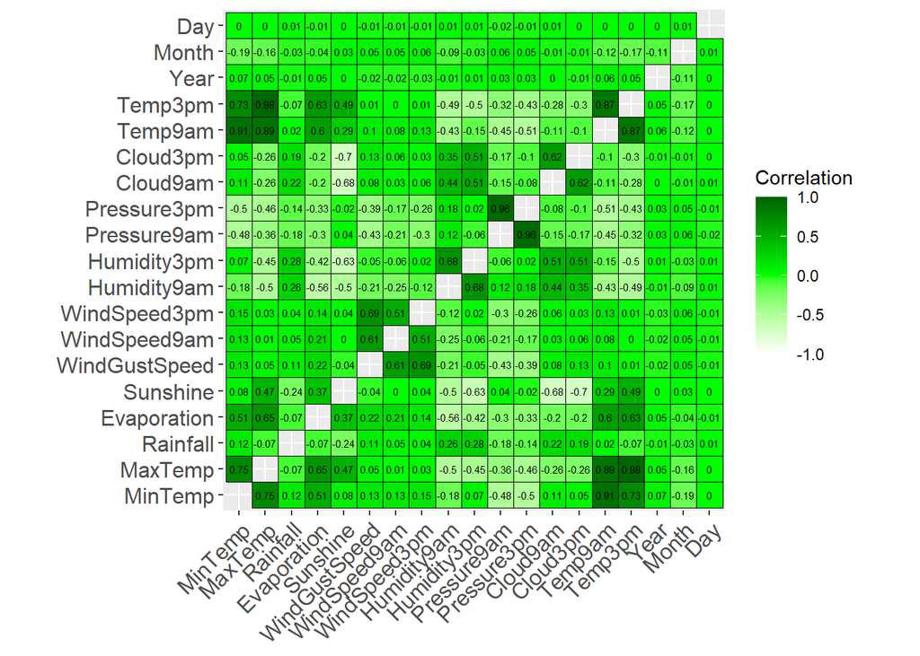

Figure 1: Correlation Heatmap

```r
weatherAusNew %>% select(where(is.numeric)) %>% model.matrix(~0+.,
              data=.) %>%
    cor(use="pairwise.complete.obs") %>%
    ggcorrplot(show.diag = FALSE, type="full",
               lab=TRUE,legend.title = "Correlation" ,lab_size
               = 2,lab_col = "black" ,ggtheme =
                 ggplot2::theme_gray,
               colors = c("white","green","darkgreen"),
               outline.color = "black")

write.csv(weatherAusNew, file = "weatherNewToPython.csv", row.names = FALSE)
colnames(weatherAusNew)
```

#### Outliers & Missing Values

> Outliers

After drawing a boxplot for each numerical attribute in the dataset, we compared the mean of each column with the min/max value and we have noticed that that attributes **Rainfall**, **Evaporation**, **WindSpeed9am** and **WindSpeed3pm** might have a large number of outliers as there’s a considerable difference between average value and max value. This also can be seen from their plots, as there is a huge amount of points (values) that differ from the average.  
Outliers can be identified by using some visualization tools as we have seen above, or also with some statistical methods. Once detected, outliers can be addressed by removing them, transforming the data, or using robust models less sensitive to outliers.

When implementing the models, we will split the dataset into training and testing sets. The training set will be used to train machine learning models, allowing the algorithms to learn from the data. The testing set, on the other hand, will be used to evaluate the models’ performance on unseen data, ensuring that the models generalize well and provide accurate predictions in real-world scenarios.

> Missing Values

Addressing missing values is crucial during data preprocessing. Missing values can result from data entry errors, collection issues, and they can degrade performance. Because of this we are going to impute the missing values at each implementation of the three models. **Missing values in categorical columns** will be filled up using the Python function **mode()** that fills in the cells with the most common/occuring element from all other instances. **Missing values in numerical columns** will be filled up with the median value from all the values of the other instances.

## Modeling

After performing the Exploratory Data Analysis, we will proceed to the modeling part. In this phase we will implement three models: **Artificial Neural Network**, **CatBoost**, and **Logistic Regression**.

Till now the analysis was made using code chunks performed in R langauge. For this implementation part the models will be implemented in Python.

### Artificial Neural Network

- The ANN model derives from Biological neural networks that have the structure of the human brain. It contains neurons(nodes) interconnected to one another in various layers of the network. It consists of three layers: Input layer, Hidden layers (can be several of them) and Output layer. The input layer accepts inputs in several formats, the hidden layer is in-between the inputs and outputs and performs calculations to find hidden features and patterns. The output layer outputs the results of calculations.

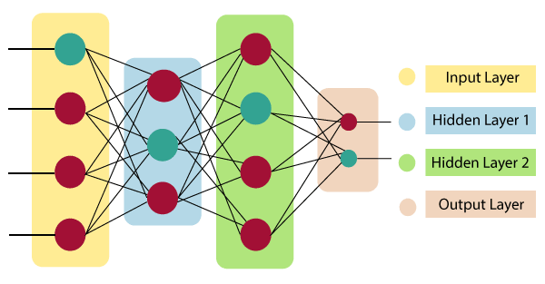

  ANN layers

- *ADVANTAGES*
  - **Parallel processing**
  - Information can produce **output** even with **inadequate data**
  - **Success** proportional to **chosen instances**
- *DISADVANTAGES*
  - Depends on **hardware**
  - ANNs work with **numerical data**
  - Duration of network is **unknown**
- **FUNCTIONING**

  Each input is multiplied by its corresponding weights (strength of interconnections between neurons). All weighted inputs are summarized inside the computing unit. Each neuron has its **bias,** which is added to the weighted sum to make it non-zero, so the total sum of weighted inputs can be from 0 to plus infinity. The maximum value is **benchmarked** to keep the response in the limits. This is performed in *TRANSFER FUNCTIONS.*

  *ACTIVATION FUNCTIONS* choose whether a node should fire or not. Only those who are *fired* make it to the output layer. Activation functions are distinctive depending on the task that is performed.
- **FEED-BACK**
  - Feed-back networks feed information back to itself
- **FEED-FORWARD**
  - Assessment of ouputs by reviewing its inputs
  - Input –> Neuron layer –> Output

```python
# ANN IMPLEMENTATIONN
import pandas as pd
import numpy as np
import seaborn as sns
from catboost import CatBoostClassifier, Pool
from sklearn.impute import SimpleImputer
from sklearn.compose import ColumnTransformer
from sklearn.pipeline import Pipeline
from sklearn.linear_model import LogisticRegression
from matplotlib import pyplot as plt
from sklearn.model_selection import train_test_split
from sklearn.metrics import classification_report, confusion_matrix, accuracy_score
from sklearn.preprocessing import StandardScaler
from keras.layers import Dense, BatchNormalization, Dropout
from keras.models import Sequential
from keras import callbacks
from keras.optimizers import Adam
from sklearn.preprocessing import LabelEncoder, StandardScaler, OneHotEncoder

df = pd.read_csv('weatherNewToPython.csv')

# Categorical columns
s = (df.dtypes == "object")
cat_cols = list(s[s].index)

print("Categorial variables")
```

```
Categorial variables
```

```python
print(cat_cols)
```

```
['Location', 'WindGustDir', 'WindDir9am', 'WindDir3pm', 'RainToday', 'RainTomorrow']
```

```python
for cols in cat_cols:

    df[cols] = df[cols].fillna(df[cols].mode()[0])

# Numerical columns
t = (df.dtypes == "float64")
num_cols = list(t[t].index)

print("Numeric variables:")
```

```
Numeric variables:
```

```python
print(num_cols)
```

```
['MinTemp', 'MaxTemp', 'Rainfall', 'Evaporation', 'Sunshine', 'WindGustSpeed', 'WindSpeed9am', 'WindSpeed3pm', 'Humidity9am', 'Humidity3pm', 'Pressure9am', 'Pressure3pm', 'Cloud9am', 'Cloud3pm', 'Temp9am', 'Temp3pm']
```

```python
for cols in num_cols:

    df[cols] = df[cols].fillna(df[cols].median())
df.info()
```

```
<class 'pandas.core.frame.DataFrame'>
RangeIndex: 145460 entries, 0 to 145459
Data columns (total 25 columns):
 #   Column         Non-Null Count   Dtype
---  ------         --------------   -----
 0   Location       145460 non-null  object
 1   MinTemp        145460 non-null  float64
 2   MaxTemp        145460 non-null  float64
 3   Rainfall       145460 non-null  float64
 4   Evaporation    145460 non-null  float64
 5   Sunshine       145460 non-null  float64
 6   WindGustDir    145460 non-null  object
 7   WindGustSpeed  145460 non-null  float64
 8   WindDir9am     145460 non-null  object
 9   WindDir3pm     145460 non-null  object
```

[output cut: 17 more lines]

```python
df.head(10)
```

```
  Location  MinTemp  MaxTemp  Rainfall  ...  RainTomorrow  Year Month  Day
0   Albury     13.4     22.9       0.6  ...            No  2008    12    1
1   Albury      7.4     25.1       0.0  ...            No  2008    12    2
2   Albury     12.9     25.7       0.0  ...            No  2008    12    3
3   Albury      9.2     28.0       0.0  ...            No  2008    12    4
4   Albury     17.5     32.3       1.0  ...            No  2008    12    5
5   Albury     14.6     29.7       0.2  ...            No  2008    12    6
6   Albury     14.3     25.0       0.0  ...            No  2008    12    7
7   Albury      7.7     26.7       0.0  ...            No  2008    12    8
8   Albury      9.7     31.9       0.0  ...           Yes  2008    12    9
9   Albury     13.1     30.1       1.4  ...            No  2008    12   10

[10 rows x 25 columns]
```

```python
# Categorical columns of type "object" into "float64"
label_encoder = LabelEncoder()
for cols in cat_cols:
    df[cols] = label_encoder.fit_transform(df[cols])


df.info()
```

```
<class 'pandas.core.frame.DataFrame'>
RangeIndex: 145460 entries, 0 to 145459
Data columns (total 25 columns):
 #   Column         Non-Null Count   Dtype
---  ------         --------------   -----
 0   Location       145460 non-null  int32
 1   MinTemp        145460 non-null  float64
 2   MaxTemp        145460 non-null  float64
 3   Rainfall       145460 non-null  float64
 4   Evaporation    145460 non-null  float64
 5   Sunshine       145460 non-null  float64
 6   WindGustDir    145460 non-null  int32
 7   WindGustSpeed  145460 non-null  float64
 8   WindDir9am     145460 non-null  int32
 9   WindDir3pm     145460 non-null  int32
```

[output cut: 17 more lines]

```python
# dropping target and extra columns
features = df.drop(['RainTomorrow', 'Year','Month', 'Day'], axis=1)
target = df['RainTomorrow']

X = features
y = target

# Splitting test and training sets
X_train, X_test, y_train, y_test = train_test_split(X, y, test_size = 0.2, random_state = 42)

X.shape
```

```
(145460, 21)
```

```python
#Early stopping
early_stopping = callbacks.EarlyStopping(
    min_delta=0.001, # minimium amount of change to count as an improvement
    patience=20, # how many epochs to wait before stopping
    restore_best_weights=True,
)

# Initialising the Neural Network
model = Sequential()

# Adding layers to the network
model.add(Dense(units = 32, kernel_initializer = 'uniform', activation = 'relu', input_dim = 21))
model.add(Dense(units = 32, kernel_initializer = 'uniform', activation = 'relu'))
model.add(Dense(units = 16, kernel_initializer = 'uniform', activation = 'relu'))
model.add(Dropout(0.25))
model.add(Dense(units = 8, kernel_initializer = 'uniform', activation = 'relu'))
model.add(Dropout(0.5))
model.add(Dense(units = 1, kernel_initializer = 'uniform', activation = 'sigmoid'))

# Compiling the ANN
opt = Adam(learning_rate=0.001)
model.compile(optimizer = opt, loss = 'binary_crossentropy', metrics = ['accuracy'])

# Train the ANN
history = model.fit(X_train, y_train, batch_size = 32, epochs = 150, callbacks=[early_stopping], validation_split=0.2)
```

[output not shown]

[output cut: 3605 more lines]

[output not shown]

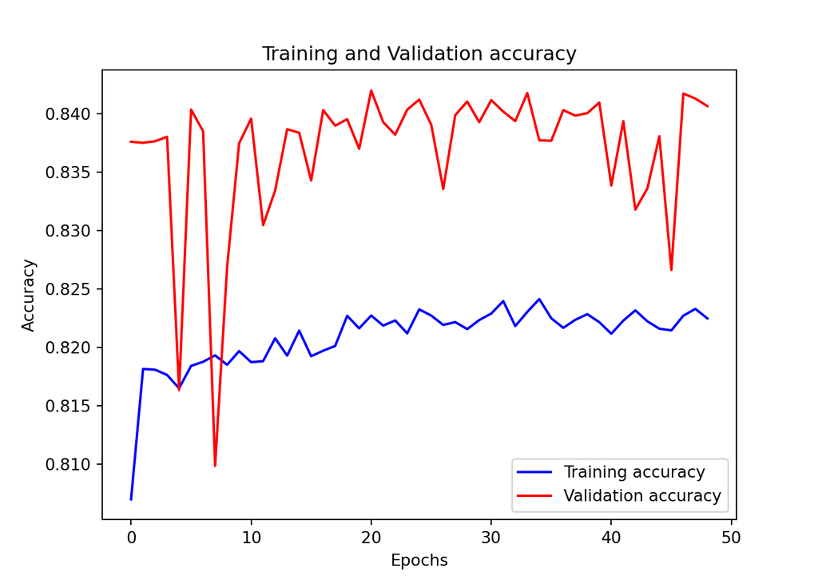

```python
# Plotting the TRAINING & VALIDATION accuracy
history_df = pd.DataFrame(history.history)

plt.plot(history_df.loc[:, ['accuracy']], "blue", label='Training accuracy')
plt.plot(history_df.loc[:, ['val_accuracy']], "red", label='Validation accuracy')

plt.title('Training and Validation accuracy')
plt.xlabel('Epochs')
plt.ylabel('Accuracy')
plt.legend()
plt.show()
```

```python
# Predicting the test set results
y_pred = model.predict(X_test)
```

[output not shown]

```python
y_pred = (y_pred > 0.5)
accuracy = accuracy_score(y_test, y_pred)
print("Accuracy:", accuracy)
```

```
Accuracy: 0.8376873367248728
```

```python
print(classification_report(y_test, y_pred))
```

```
              precision    recall  f1-score   support

           0       0.85      0.96      0.90     22672
           1       0.74      0.40      0.52      6420

    accuracy                           0.84     29092
   macro avg       0.80      0.68      0.71     29092
weighted avg       0.83      0.84      0.82     29092
```

### CatBoost

- Catboost is a machine learning algorithm that excels in classification and regression tasks. As a **gradient boosting** algorithm, it builds an ensemble of decision trees, where each tree corrects the errors of the previous ones. This iterative process enhances the model’s accuracy and robustness.
- **FUNCTIONING**

  Catboost follows the principles of gradient boosting but introduces several unique innovations:
  - *Initialization:* The algorithm begins with a simple initial model, such as predicting the **mean value** for regression or **uniform probability** for classification.
  - *Sequential Tree Building:* Decision trees are constructed one by one. Each tree is designed to minimize a specified loss function by addressing the errors from previous trees.
  - *Model Update:* Newly built tree is added to the model, refining it.
  - *Iteration:* The process repeats until the stopping criterion is met.
- **Key Concepts:**
  - Gradient Boosting: Ensemble learning technique that combines weak prediction models, typically prediction trees, to form a strong predictive model. It iteratively adds new models to the ensemble.
  - Handling Categorical Features: It handles categorical features directly, without requiring extensive preprocessing. Very effective for real-world datasets that contain qualitative data, improving the performance.
  - Learning Rate: The learning rate in CatBoost controls the step size at which the model learns during boosting. CatBoost automatically selects an optimal learning rate based on the dataset’s features, striking a **balance** between **learning speed** and **model accuracy.** This helps achieving better performance with minimal tuning.

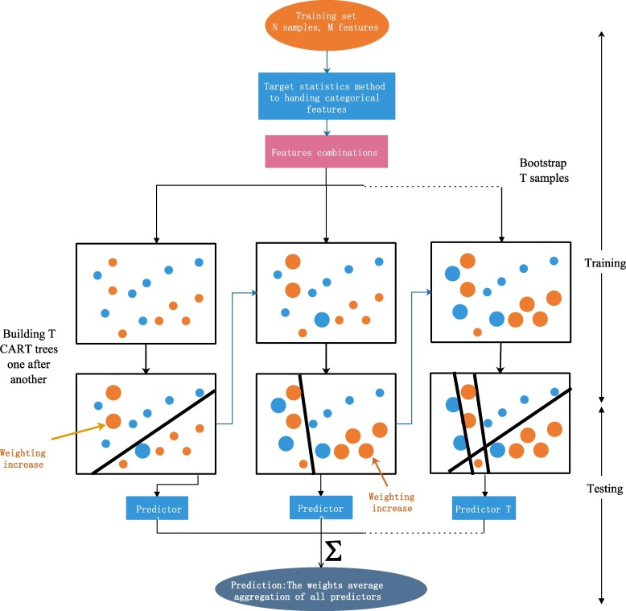

  Sequential Tree Building approach

```python
# Load data
data = pd.read_csv("weatherAUS.csv")

# Define columns with missing values
numeric_features = data.select_dtypes(include=['float64', 'int64']).columns
categorical_features = data.select_dtypes(include=['object']).columns

# Fill missing values
for col in numeric_features:
    data[col] = data[col].fillna(data[col].median())

for col in categorical_features:
    data[col] = data[col].fillna(data[col].mode()[0])

# Prepare features and labels
X = data.drop(columns=['RainTomorrow'])
y = data['RainTomorrow']

# Ensure that 'RainTomorrow' is not included in categorical_features
categorical_features = [col for col in categorical_features if col != 'RainTomorrow']

# Split the data
X_train, X_test, y_train, y_test = train_test_split(X, y, test_size=0.2, random_state=42)

# Create CatBoost Pool
train_pool = Pool(data=X_train, label=y_train, cat_features=categorical_features)
test_pool = Pool(data=X_test, label=y_test, cat_features=categorical_features)

# Initialize CatBoost model
model = CatBoostClassifier(iterations=100, depth=6, learning_rate=0.1, loss_function='Logloss', verbose=True)

# Train the model
model.fit(train_pool)
```

```
0:  learn: 0.6270827    total: 315ms    remaining: 31.2s
1:  learn: 0.5717355    total: 430ms    remaining: 21s
2:  learn: 0.5288813    total: 514ms    remaining: 16.6s
3:  learn: 0.4973616    total: 594ms    remaining: 14.3s
4:  learn: 0.4714247    total: 689ms    remaining: 13.1s
5:  learn: 0.4506941    total: 796ms    remaining: 12.5s
6:  learn: 0.4342015    total: 868ms    remaining: 11.5s
7:  learn: 0.4215802    total: 932ms    remaining: 10.7s
8:  learn: 0.4108237    total: 1.01s    remaining: 10.2s
9:  learn: 0.4027844    total: 1.12s    remaining: 10.1s
10: learn: 0.3964012    total: 1.23s    remaining: 9.94s
11: learn: 0.3904812    total: 1.33s    remaining: 9.79s
12: learn: 0.3857214    total: 1.41s    remaining: 9.45s
13: learn: 0.3821417    total: 1.52s    remaining: 9.33s
14: learn: 0.3791560    total: 1.6s remaining: 9.05s
```

[output cut: 86 more lines]

```python
# Get evaluation results
evals_result = model.get_evals_result()

# Print the loss at each iteration
losses = evals_result['learn']['Logloss']
for i, loss in enumerate(losses):
    print(f'Iteration {i}: Loss = {loss}')
```

```
Iteration 0: Loss = 0.6270827237767883
Iteration 1: Loss = 0.5717354793926579
Iteration 2: Loss = 0.5288812628855518
Iteration 3: Loss = 0.4973616233888124
Iteration 4: Loss = 0.4714247258482001
Iteration 5: Loss = 0.4506941309414565
Iteration 6: Loss = 0.4342015017759755
Iteration 7: Loss = 0.42158016843606083
Iteration 8: Loss = 0.4108236964050978
Iteration 9: Loss = 0.4027843769336262
Iteration 10: Loss = 0.3964011539734376
Iteration 11: Loss = 0.3904811695456526
Iteration 12: Loss = 0.3857213945284449
Iteration 13: Loss = 0.38214174768108533
Iteration 14: Loss = 0.37915597470494844
Iteration 15: Loss = 0.3756302421858873
Iteration 16: Loss = 0.3729288881969476
Iteration 17: Loss = 0.37089550581782865
Iteration 18: Loss = 0.3682472406955625
Iteration 19: Loss = 0.36618560966383606
Iteration 20: Loss = 0.36437285404104275
Iteration 21: Loss = 0.36274449459763336
Iteration 22: Loss = 0.3612535036541703
Iteration 23: Loss = 0.36007523330820534
Iteration 24: Loss = 0.3588005188854733
Iteration 25: Loss = 0.35776978436870616
Iteration 26: Loss = 0.3565534161036887
Iteration 27: Loss = 0.3557328195813623
Iteration 28: Loss = 0.3549938433377035
Iteration 29: Loss = 0.354229739887142
Iteration 30: Loss = 0.3535394131996704
Iteration 31: Loss = 0.35295974960899706
Iteration 32: Loss = 0.3523278904852756
Iteration 33: Loss = 0.35174578694864356
Iteration 34: Loss = 0.3512072485769523
Iteration 35: Loss = 0.3508271928376375
Iteration 36: Loss = 0.3503401363739203
Iteration 37: Loss = 0.3499322739748575
Iteration 38: Loss = 0.34928546614639683
Iteration 39: Loss = 0.3487487752654309
```

[output cut: 45 more lines]

```
Iteration 85: Loss = 0.33669996281432946
Iteration 86: Loss = 0.3365667917803073
Iteration 87: Loss = 0.33641864645578584
Iteration 88: Loss = 0.33626733591787766
Iteration 89: Loss = 0.33613197490343427
Iteration 90: Loss = 0.33583206856058956
Iteration 91: Loss = 0.33571723342677906
Iteration 92: Loss = 0.3355988366380124
Iteration 93: Loss = 0.3354584312006883
Iteration 94: Loss = 0.33527819696879657
Iteration 95: Loss = 0.33507752803669977
Iteration 96: Loss = 0.3349315124033232
Iteration 97: Loss = 0.3346552828256837
Iteration 98: Loss = 0.3345161257026082
Iteration 99: Loss = 0.33435455914758744
```

```python
# Make predictions
preds = model.predict(test_pool)

# Evaluate the model
accuracy = (preds == y_test).mean()
print(f'Accuracy: {accuracy}')
```

```
Accuracy: 0.8512649525642788
```

```python
print(classification_report(y_test, preds))
```

```
              precision    recall  f1-score   support

          No       0.87      0.95      0.91     22672
         Yes       0.74      0.50      0.60      6420

    accuracy                           0.85     29092
   macro avg       0.81      0.73      0.75     29092
weighted avg       0.84      0.85      0.84     29092
```

### Logistic Regression

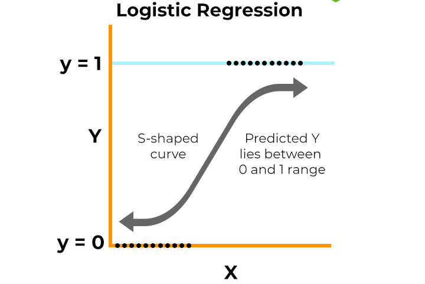

    Sigmoid Function

- **Sigmoid function** is a mathematical function used to map the predicted values to probabilities. It maps any real value into another value within the range of 0 and 1. This range is called the **Threshold value**.
- **Types of Logistic regression**
  - Binomial: there can be only two possible types of dependent variables, such as 0 and 1, Pass or Fail, etc.
  - Multinomial: there can be 3 or more possible unordered types of the dependent variable, such as “cat”, “dogs”, or “sheep”.
  - Ordinal: there can be 3 or more possible ordered types of dependent variables, such as “low”, “medium”, “high”.

```python
data = pd.read_csv("weatherAUS.csv")

# Define numerical and categorical columns
numerical_cols = ['MinTemp', 'MaxTemp', 'Rainfall', 'Evaporation', 'Sunshine', 'WindGustSpeed', 'WindSpeed9am',
                  'WindSpeed3pm', 'Humidity9am', 'Humidity3pm', 'Pressure9am', 'Pressure3pm', 'Cloud9am', 'Cloud3pm',
                  'Temp9am', 'Temp3pm']

categorical_cols = ['WindGustDir', 'WindDir9am', 'WindDir3pm', 'RainToday']


# Preprocessing for numerical data: Impute missing values with median and scale
numerical_transformer = Pipeline(steps=[
    ('imputer', SimpleImputer(strategy='median')),
    ('scaler', StandardScaler())
])


# Preprocessing for categorical data: Impute missing values with mode and one-hot encode
categorical_transformer = Pipeline(steps=[
    ('imputer', SimpleImputer(strategy='most_frequent')),
    ('onehot', OneHotEncoder(handle_unknown='ignore'))
])


# Bundle preprocessing for numerical and categorical data
preprocessor = ColumnTransformer(
    transformers=[
        ('num', numerical_transformer, numerical_cols),
        ('cat', categorical_transformer, categorical_cols)
    ])

# Prepare the data
X = data.drop(columns=['Date', 'Location', 'RainTomorrow'])
y = data['RainTomorrow']

# Apply label encoding to the target variable
label_encoder = LabelEncoder()
y = label_encoder.fit_transform(y)

# Split the data into training and testing sets
X_train, X_test, y_train, y_test = train_test_split(X, y, test_size=0.2, random_state=42)

# Create and train the logistic regression model
model = Pipeline(steps=[
    ('preprocessor', preprocessor),
    ('classifier', LogisticRegression(max_iter=1000))
])

model.fit(X_train, y_train)
```

```
Pipeline(steps=[('preprocessor',
                 ColumnTransformer(transformers=[('num',
                                                  Pipeline(steps=[('imputer',
                                                                   SimpleImputer(strategy='median')),
                                                                  ('scaler',
                                                                   StandardScaler())]),
                                                  ['MinTemp', 'MaxTemp',
                                                   'Rainfall', 'Evaporation',
                                                   'Sunshine', 'WindGustSpeed',
                                                   'WindSpeed9am',
                                                   'WindSpeed3pm',
                                                   'Humidity9am', 'Humidity3pm',
                                                   'Pressure9am', 'Pressure3pm',
                                                   'Cloud9am', 'Cloud3pm',
                                                   'Temp9am', 'Temp3pm']),
                                                 ('cat',
                                                  Pipeline(steps=[('imputer',
                                                                   SimpleImputer(strategy='most_frequent')),
                                                                  ('onehot',
                                                                   OneHotEncoder(handle_unknown='ignore'))]),
                                                  ['WindGustDir', 'WindDir9am',
                                                   'WindDir3pm',
                                                   'RainToday'])])),
                ('classifier', LogisticRegression(max_iter=1000))])
```

```python
# Make predictions
y_pred = model.predict(X_test)

# Evaluate the model
accuracy = accuracy_score(y_test, y_pred)
conf_matrix = confusion_matrix(y_test, y_pred)
class_report = classification_report(y_test, y_pred, zero_division=0)

print("Accuracy:", accuracy)
```

```
Accuracy: 0.8231472569778633
```

```python
print("Confusion Matrix:\n", conf_matrix)
```

```
Confusion Matrix:
 [[20779  1233     0]
 [ 3252  3168     0]
 [  584    76     0]]
```

```python
print("Classification Report:\n", class_report)
```

```
Classification Report:
               precision    recall  f1-score   support

           0       0.84      0.94      0.89     22012
           1       0.71      0.49      0.58      6420
           2       0.00      0.00      0.00       660

    accuracy                           0.82     29092
   macro avg       0.52      0.48      0.49     29092
weighted avg       0.79      0.82      0.80     29092
```

## Conclusion

Logistic Regression, while the simplest of the three models, achieved an accuracy of 0.82. This model may have performed worse than the other two models, because of its linear nature, which may not fully captured the complexities of the data as effectively. Logistic Regression remains a valuable model due to its simplicity and lower computational cost.